# Normal Probability / Sampling Distribution

Sulalitha Bowala

Here, we use R to demonstrate how to calculate probabilities and quantiles related to the Normal distribution (without the use of a table). That is how to calculate Normal probabilities and how to find quantiles (z-value) of the Normal distribution in R.

## Normal Probability

### “pnorm()” (Probability Density Function)

The **pnorm()** function calculates the probability of a random variable following a normal distribution. In other words, it gives you the probability that a value from a standard normal distribution is less than or equal to a specified value.

**Syntax**: pnorm(q, mean = 0, sd = 1, lower.tail = TRUE)

- q: The quantile or value for which you want to calculate the probability.
- mean: The mean of the normal distribution (default is 0 for the standard normal distribution).
- sd: The standard deviation of the normal distribution (default is 1 for the standard normal distribution).
- lower.tail: A logical value indicating whether to calculate the probability for values less than or equal to q (default is TRUE). If FALSE, it calculates the probability for values greater than q.

Examples:

1. $P(Z<0.5)$ where $Z$ is a standard normal random variable (Standard normal random variable has mean $0$ and standard deviation $1$).

```r
pnorm(q = 0.5, mean = 0, sd = 1)
```

```
## [1] 0.6914625
```

**Note**: For standard normal random variables, we do not need to specify mean and standard deviation. Because default values of mean and sd arguments in the “pnorm()” function are $0$ and $1$, respectively.

```r
pnorm(q = 0.5)
```

```
## [1] 0.6914625
```

Also, even if you do not mention the argument name, the function “pnorm()” can still identify the quantile or value for which you want to calculate the probability.

```r
pnorm(0.5)
```

```
## [1] 0.6914625
```

2. $P(Z>0.7)$ where $Z$ is a standard normal random variable.

Recall that the **pnorm()** function calculates the probability the standard normal distribution is less than or equal to a specified value by default. Thus, to find a probability greater than equal to a specified value we have two options.

Option 1: $1-P(Z<0.7)$

```r
1-pnorm(q = 0.7)
```

```
## [1] 0.2419637
```

Option 2: Use the argument “lower.tail = FALSE”

```r
pnorm(q = 0.7, mean = 0, sd = 1, lower.tail = FALSE)
```

```
## [1] 0.2419637
```

### “qnorm()” (Quantile Function)

The **qnorm()** function does the opposite of “pnorm()”. It calculates the quantile or value for a given probability in a normal distribution. In other words, it helps you find the value such that a specified proportion of the distribution falls below that value.

**Syntax**: qnorm(p, mean = 0, sd = 1, lower.tail = TRUE)

- p: The cumulative probability for which you want to find the quantile.
- mean: The mean of the normal distribution (default is 0 for the standard normal distribution).
- sd: The standard deviation of the normal distribution (default is 1 for the standard normal distribution).
- lower.tail: A logical value indicating whether to find the quantile for values less than or equal to p (default is TRUE). If FALSE, it finds the quantile for values greater than p.

Examples:

1. Find the z-value such that $P(Z < z) = 0.3409$.

```r
qnorm(p = 0.3409, mean = 0, sd = 1)
```

```
## [1] -0.4100081
```

```r
qnorm(p = 0.3409)
```

```
## [1] -0.4100081
```

When you use “pnorm()” and “qnorm()” functions without specifying the mean (mean) and standard deviation (sd) arguments, the functions assume you are working with the standard normal distribution.

However, “pnorm()” and “qnorm()” functions are not limited to the standard normal distribution. You can use them to work with any normal distribution by specifying the mean (mean) and standard deviation (sd) that correspond to your specific distribution.

Example:

Suppose that percentage grades in a large Calculus class follow a Normal distribution with a mean of 64 and a standard deviation of 12. What proportion of students fail this course (i.e., receive a grade below 50)?

If we let $X$ represent the grade of a random student selected from this course, then we know that $X∼N(64,12)$. To solve this question, we have to calculate $P(X<50)$.

```r
pnorm(q = 50, mean = 64, sd = 12)
```

```
## [1] 0.1216725
```

We can see directly that the proportion of students who fail this course is $0.1217$. There is no need to standardize or use a table. Also, we do not have to worry about rounding errors when calculating with software.

Suppose that students in the bottom 10% of grades in this class are required to take a remedial math course before re-attempting the calculus course. What is the grade cutoff to receive this email?

To solve this problem, we are looking to find the value $x$ such that $P(X<x)=0.10$

```r
qnorm(p = 0.1, mean = 64, sd = 12)
```

```
## [1] 48.62138
```

## Sampling Distributions

In order to investigate the behavior of sampling distributions, we will load in the Lightning dataset, which contains information from a lightning storm. In particular, it gives the time (in seconds) between consecutive lightning strikes.

```r
Lightning <- read.csv("Lightning.csv")
```

Let’s get quick understanding of this dataset.

```r
mean(Lightning$Time)
```

```
## [1] 8
```

```r
sd(Lightning$Time)
```

```
## [1] 8
```

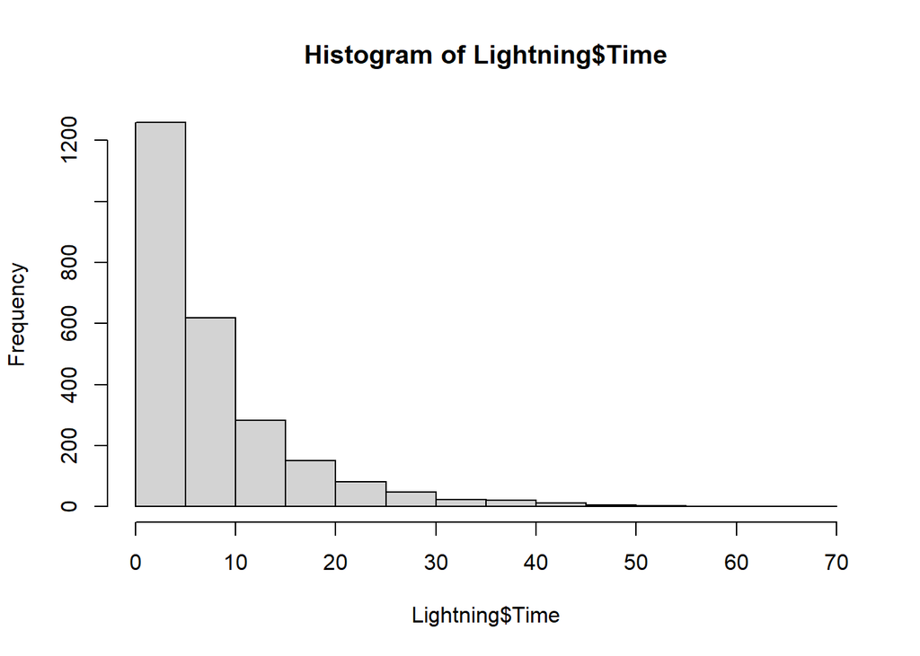

```r
hist(Lightning$Time, breaks = 20)
```

We can see that this dataset is heavily right-skewed.

According to the central limit theorem, if we took a large sample ($n=100$) of observations from this distribution and measured the sample mean $\bar{X}$, we would expect this sample mean to come from an (approximate) Normal distribution. That Normal distribution should have a mean of $\mu_{\bar{X}}=\mu_{X}=8$, and a standard deviation of $\sigma_{\bar{X}}=\frac{\sigma_{X}}{\sqrt{n}}=\frac{8}{\sqrt{100}}=0.8$. That is $\bar{X} \sim N(8, 0.8)$.

We need to replicate the above process many times in order to construct a sampling distribution (histogram) for the sample mean.

We know from Lab 3 we can take a sample of size 100 from the Lightning dataset using the “sample()” function.

**Syntax**: sample(x = Lightning$Time, size = 100, replace = FALSE, …)

Then, for the chosen data, we will calculate the sample mean.

**Syntax**: mean(sample(x = Lightning$Time, size = 100, replace = FALSE, …))

We can use the replicate function to repeat the above process and create a vector of results.

In R, the **replicate()** function is used to replicate the execution of an expression multiple times and collect the results into a vector. It is particularly useful for generating multiple random samples or conducting simulations.

**Syntax**: replicate(n, expr, …)

- n: The number of times to replicate the expression.
- expr: The expression to be evaluated and replicated.

Suppose that we take a small sample, say of size $n=4$. Let’s use the process above to see what the sampling distribution of the sample mean would be in this case.

**Note that we are taking 5000 sample from Lightning and size of each sample is 4**.

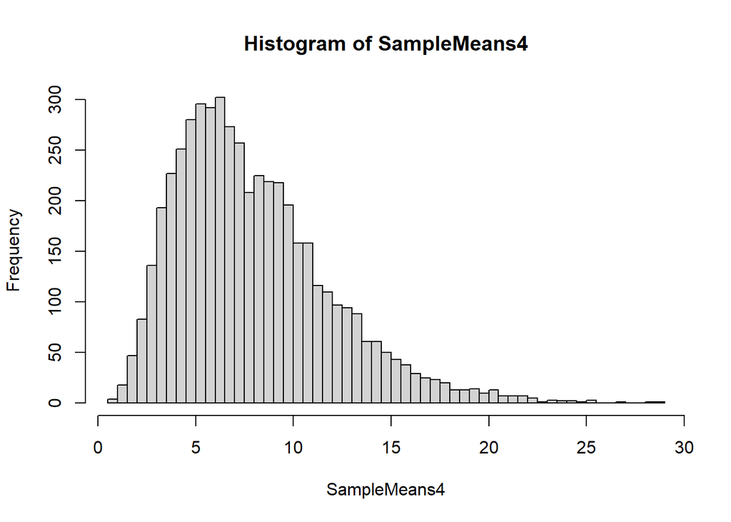

```r
SampleMeans4 = replicate(n = 5000, expr = mean(sample(Lightning$Time, 4)))
hist(SampleMeans4, breaks = 50)
```

We can see here that $n=4$ is not enough to give us Normality in $\bar{X}$.

We will try again with our usual recommendation, n=30 (large sample size).

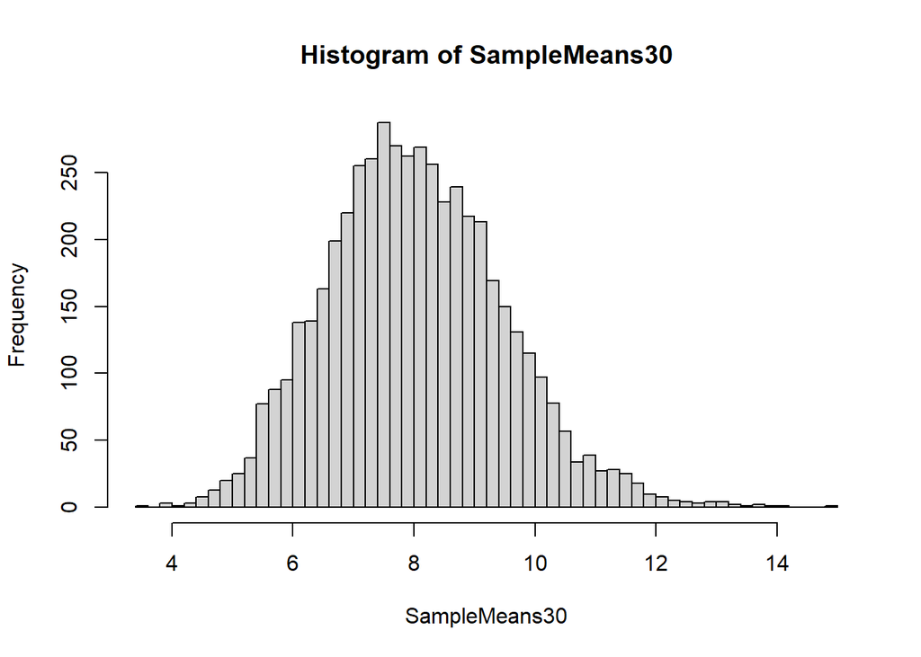

```r
SampleMeans30 = replicate(n = 5000, expr = mean(sample(Lightning$Time, 30)))
hist(SampleMeans30, breaks = 50)
```

We can see that this distribution looks quite Normal.

Let’s look at the sampling distribution of the sample mean with $n=100$.

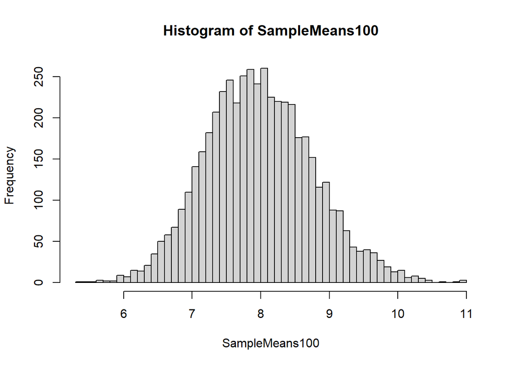

```r
SampleMeans100 = replicate(n = 5000, expr = mean(sample(Lightning$Time, 100)))
hist(SampleMeans100, breaks = 50)
```

The mean and standard deviation of the sampling distribution are very close to the values suggested by the central limit theorem.

```r
mean(SampleMeans100)
```

```
## [1] 7.986342
```

```r
sd(SampleMeans100)
```

```
## [1] 0.7856146
```

Suppose we were to take a sample of $n=50$ consecutive strikes and measure the time between them. What is the probability that the mean inter-strike time is less than 9 seconds?

```r
pnorm(q = 9, mean = 8, sd = 8/sqrt(50))
```

```
## [1] 0.8116204
```

Suppose we were to take a sample of $n=50$ consecutive strikes and again measure the mean inter-strike time. There is a 95% chance that this mean will fall below what value?

```r
qnorm(p = 0.95, mean = 8, sd = 8/sqrt(50))
```

```
## [1] 9.860939
```